# MIDI-MT - Отладка при написании сценариев «ChaiScript»

MIDI-MT Документация на Русском языке

## «ChaiScript» - Отладка и создание сценариев

- Отладка при написании собственных сценариев
- Управление **MMTScript Tester** :
  - Ключи командной строки
  - Команды клавиш управления
  - Командная строка управления
- ChaiScript - документация и примеры
- Специфические объекты MIDI-MT API в сценариях
- Назначение сценариев в MIDI-MT
- Настройки модуля управления сценариями
- Краткие сведения о основных характеристиках языка ChaiScript

```
    Скриптовым ядром MIDI-MT является ChaiScript
    ChaiScript - это типизированный декларативный язык с синтаксисом, аналогичным C++, TypeScript и JavaScript.
```

#### Отладка при написании сценариев ChaiScript

Для разработки и тестов сценариев, в дистрибутиве прилагается утилита `MMTScriptTester.exe`. Вы можете использовать её для отладки при написании собственных сценариев. Отслеживания изменений в каталоге сценариев также работает. Сценарии в случае изменения перезагружаются автоматически. Если изменения произошли в момент выполнения любого сценария, то изменения откладываются до окончания его работы.  
Время последней модификации файла сценария, отображаемое в списке соответствует времени его последней загрузки. Это не время реальной даты изменения файла на диске.

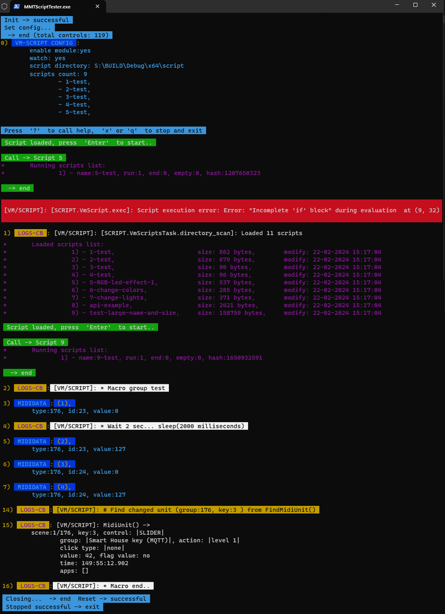

Управление `MMTScript Tester` интуитивно понятное и исходит из концепции минимизации колличества команд до необходимого размера, чтобы не перегружать интерфейс и снизить порог вхождения для использующих.

Для смыслового разграничения отображаемых текстов, используются различные цвета, что облегчает восприятие при большом потоке отладочной иформации во время запуска скрипта.

Работа программы рассчитана на параллельную работу с любым удобным для вас редактором, в котором вы можете редактировать сценарии.

### Управление MMTScript Tester

`MMTScript Tester` имеет три вида управления:

- при запуске можно задать конфигурацию ключами в командной строке,
- с помощью одиночных клавиш, режим по умолчанию,
- с помощью командной строки, которая вызывается двойным нажатием `Enter`.

##### Ключи командной строки при запуске MMTScript Tester

```
  Usage: MMTScriptTester.exe [options...]
  Options:
    -d, --directory        Установить каталог сценариев, полный путь
    -r, --run              Запуск сценария по номеру, действительные номера от 1 до 9
    -o, --open             Запускать скрипт по имени, требуется полный путь к файлу
    -w, --watch            Включить наблюдение за изменениями сценариев
    -b, --debug            Установить вывод отладки скрипта в специальную программу
    -s, --no-string-lib    Не использовать библиотеки строк
    -u, --no-wstring-lib   Не использовать библиотеки wide строк
    -m, --no-math-lib      Не использовать математические библиотеки
    -h, --help             Эта страница помощи..
```

##### Команды клавиш управления MMTScript Tester

```
    '?'          Эта страница помощи..
    '1-9'        Запуск сценария по номеру, действительные номера от 1 до 9
    's'          Сканировать каталог сценариев
    'l'          Показать список загруженных скриптов
    'r'          Показать список запущенных скриптов
    'c'          Показать конфигурацию
    'b'          Показать исходный код последнего запущенного скрипта
    'd'          Установить вывод отладки скрипта в специальную программу
    't'          Завершить все запущенные сценарии
    'x' or 'q'   Остановить и выйти
    'show help'  Вызов помощи по полным строковым командам
```

В этом режиме доступен вызов только первых девяти сценариев, с номерами от 1 до 9. Если есть необходимость вызвать для выполнения более старшие номера, необходимо использовать режим `командной строки`.

##### Командная строка управления MMTScript Tester

```
    'help'                                                Эта страница помощи..
    'sh|show|print' '[list|scripts]'                      Показать список загруженных скриптов
    'sh|show|print' '[run|running|launch]'                Показать список запущенных скриптов
    'sh|show|print' '[conf|config|configuration]'         Показать конфигурацию
    'sh|show|print' '[dir|directory]'                     Показать текущий каталог скриптов
    'sh|show|print' '[src|code|source]' '[number|string]' Показать исходный код скрипта по номеру или имени
    'run|call|start [number|string]'                      Вызов сценария по номеру или имени
    'stop|end [number|string]'                            Остановить выполнение скрипта
    'scan|rescan|reload'                                  Сканировать каталог сценариев
    'terminate|term'                                      Завершить все запущенные сценарии
    'debug|debugging'                                     Установить вывод отладки скрипта в специальную программу
```

Расширенный режим управления, позволяет вызывать скрипты от 1 до 27 номера. Также возможен вызов скрипта по имени, не указывая расширение. Имеет ряд дополнительных команд.

#### Документация и примеры ChaiScript

1. Узнать больше в [документации и примерах](https://chaiscript.com/examples.html#ChaiScript_Language_Examples) на сайте `ChaiScript`.
2. Посмотреть больше [примеров кода](https://github.com/ChaiScript/ChaiScript/tree/master/unittests) `ChaiScript`.
3. [Справочник по языку](https://github.com/ChaiScript/ChaiScript/blob/develop/cheatsheet.md#language-reference) `ChaiScript`.
4. Начало работы с `ChaiScript`:
   - [PDF](https://github.com/ClaudiaCoord/MIDI-EasyControl-to-Mackie-translator-for-Premiere-Pro/tree/main/docs/API/script/Chaiscript-Overview-and-Tutorial-RU.pdf) | [сайт](https://drolliblog.wordpress.com/2017/12/22/chaiscript-overview-and-tutorial/) часть 1 - Обзор и учебные пособия,
   - [PDF](https://github.com/ClaudiaCoord/MIDI-EasyControl-to-Mackie-translator-for-Premiere-Pro/tree/main/docs/API/script/Chaiscript-Overview-and-Tutorial-Additional-RU.pdf) | [сайт](https://drolliblog.wordpress.com/2020/08/04/chaiscript-additional-topics/) часть 2 - Обзор и дополнительные учебные пособия,
   - [сайт](https://codedocs.xyz/ChaiScript/ChaiScript/LangGettingStarted.html) часть 3 - Как начать.
5. Специфические объекты MIDI-MT API в сценариях.
6. Пример [MIDI-MT API](https://github.com/ClaudiaCoord/MIDI-EasyControl-to-Mackie-translator-for-Premiere-Pro/tree/main/docs/API/script/example/example-api.mmts).
7. Примеры управления **RGB LED**:
   - [пример RGB-led эффекта](https://github.com/ClaudiaCoord/MIDI-EasyControl-to-Mackie-translator-for-Premiere-Pro/tree/main/docs/API/script/example/example-RGB-led-effect-1.mmts),
   - [изменение цвета](https://github.com/ClaudiaCoord/MIDI-EasyControl-to-Mackie-translator-for-Premiere-Pro/tree/main/docs/API/script/example/example-change-HSV-color-constant.mmts),
   - [изменение произвольного цвета](https://github.com/ClaudiaCoord/MIDI-EasyControl-to-Mackie-translator-for-Premiere-Pro/tree/main/docs/API/script/example/example-change-HSV-color.mmts),
   - [изменение яркости](https://github.com/ClaudiaCoord/MIDI-EasyControl-to-Mackie-translator-for-Premiere-Pro/tree/main/docs/API/script/example/example-change-HSV-brightness.mmts),
   - [изменение насыщенности](https://github.com/ClaudiaCoord/MIDI-EasyControl-to-Mackie-translator-for-Premiere-Pro/tree/main/docs/API/script/example/example-change-HSV-saturation.mmts).
8. Прочие примеры:
   - [пример использования «макроса»](https://github.com/ClaudiaCoord/MIDI-EasyControl-to-Mackie-translator-for-Premiere-Pro/tree/main/docs/API/script/example/example-macro-using.mmts),
   - [пример получение списка контролов из текущей конфигурации](https://github.com/ClaudiaCoord/MIDI-EasyControl-to-Mackie-translator-for-Premiere-Pro/tree/main/docs/API/script/example/example-units-list.mmts).
9. Полезные дополнения:
   - [ChaiScript language support for Notepad++](https://github.com/ChaiScript/npp-chaiscript),
   - [VsCode ChaiScript syntax](https://github.com/codehz/vscode-chaiscript-syntax),
   - [TypeScript to Chaiscript transpiler](https://github.com/Alia5/TSChai),
   - скачать `DebugView` [x64](https://live.sysinternals.com/dbgview64.exe) | [x32](https://live.sysinternals.com/Dbgview.exe) | [ZIP](https://download.sysinternals.com/files/DebugView.zip) от [sysinternals](https://learn.microsoft.com/ru-ru/sysinternals/).